# simple mapping

Kristie Ellickson

3/3/2020

## Tidy Tuesday Data - Simple Mapping and Spatial Analysis

Where are the trees? This is what I asked when I looked at the Tidy Tuesday San Francisco tree data.

```r
library(readr)
library(sf)
library(tidyverse)
tree_data <- read_csv("https://raw.githubusercontent.com/rfordatascience/tidytuesday/master/data/2020/2020-01-28/sf_trees.csv")
glimpse(tree_data)
```

```
## Observations: 192,987
## Variables: 12
## $ tree_id      <dbl> 53719, 30313, 30312, 30314, 30315, 30316, 48435, 30319...
## $ legal_status <chr> "Permitted Site", "Permitted Site", "Permitted Site", ...
## $ species      <chr> "Tree(s) ::", "Tree(s) ::", "Tree(s) ::", "Pittosporum...
## $ address      <chr> "2963 Webster St", "501 Arkansas St", "501 Arkansas St...
## $ site_order   <dbl> 1, 3, 2, 1, 5, 6, 4, 2, 1, 3, 1, 3, 1, 2, 4, 1, 1, 1, ...
## $ site_info    <chr> "Sidewalk: Curb side : Cutout", "Sidewalk: Curb side :...
## $ caretaker    <chr> "Private", "Private", "Private", "Private", "Private",...
## $ date         <date> 1955-09-19, 1955-10-20, 1955-10-20, 1955-10-20, 1955-...
## $ dbh          <dbl> NA, NA, NA, 16, NA, NA, NA, NA, NA, NA, 2, NA, NA, NA,...
## $ plot_size    <chr> NA, NA, NA, NA, NA, NA, NA, NA, NA, NA, NA, NA, NA, NA...
## $ latitude     <dbl> 37.79787, 37.75984, 37.75984, 37.75977, 37.79265, 37.7...
## $ longitude    <dbl> -122.4341, -122.3981, -122.3981, -122.3981, -122.4124,...
```

Attempt to make a geographic object:

```r
##tell R where the geometry is
tree_data <- st_as_sf(tree_data, coords = c("longitude", "latitude"), crs = 4326)
```

Woop! We’ve got some missing coordinates. Fail!

```r
##tell R where the geometry is
tree_data <- tree_data %>%
  filter(!is.na(longitude))
```

Make a geographic object:

```r
##tell R where the geometry columns are
tree_data <- st_as_sf(tree_data, coords = c("longitude", "latitude"), crs = 4326)
```

Plot the data

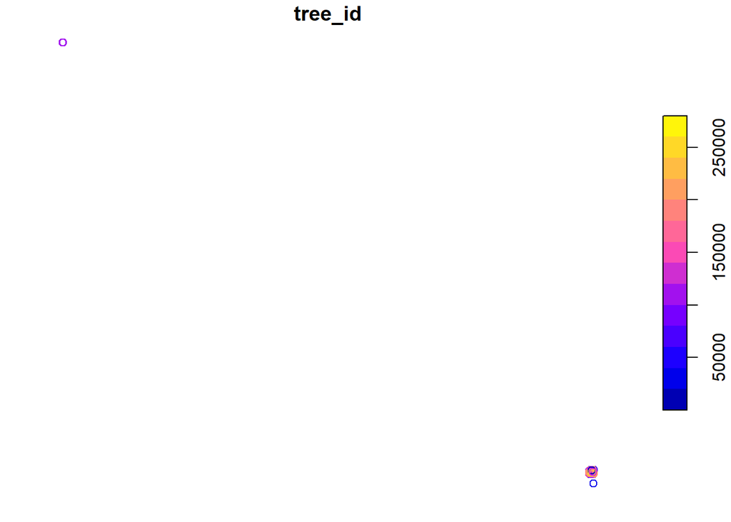

```r
plot(tree_data[1])
```

Hey! That doesn’t look like San Francisco

```r
tree_data <- tree_data %>%
  filter(latitude < 40)
```

Plot the data again

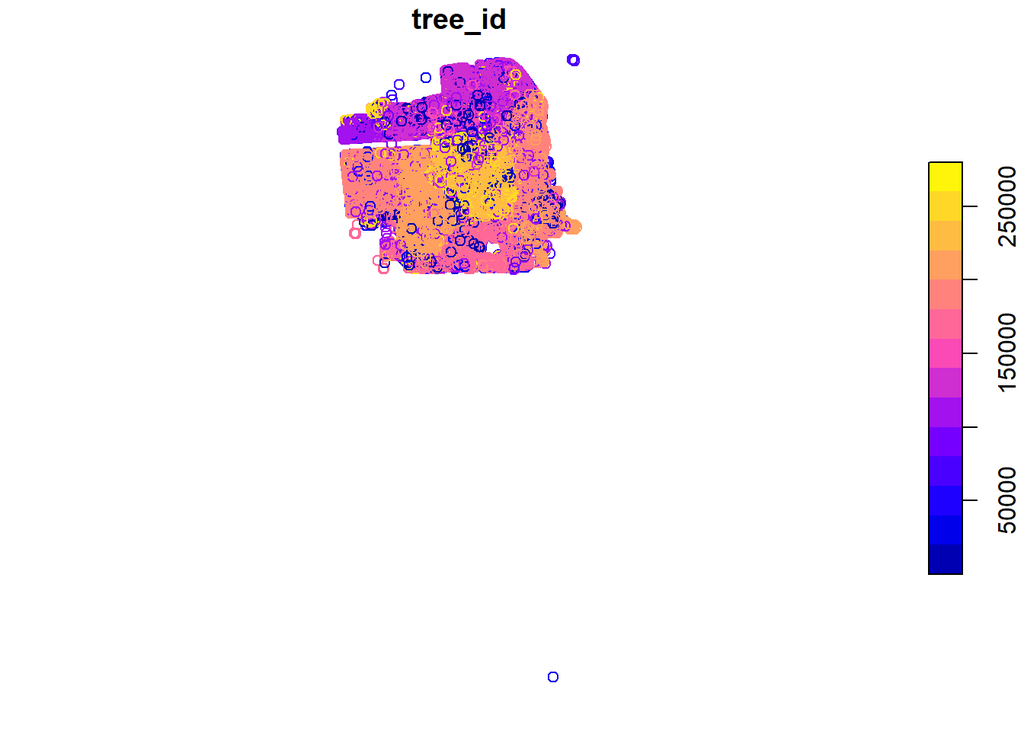

## Fun Friday Project

I decided to use the sf package in R to talk to MPCA’s water and watershed program about how we might be able to collaborate.

First I pulled in the metals risks from MNRISKS

```r
data <- read_csv("X:/Agency_Files/Outcomes/Risk_Eval_Air_Mod/_Air_Risk_Evaluation/MNRISKS/2014 MNRISKS/Results/Pollutant_totals/checking_cobalt/interim_tables/metal_risks.csv")
```

Then, I pulled in a surface water layer. I used the st_read() function from the sf package. The st_read function will guess that the driver = “ESRI Shapefile”, but if your data aren’t an ESRI SHapefile, you can include the “driver =” argument.

```r
lakes <- st_read(dsn = "R:/surface_water", layer = "dowlakes_comprehensive_dnr")
```

By reading in with st_read(), I conserve the geographic features. To prove it,

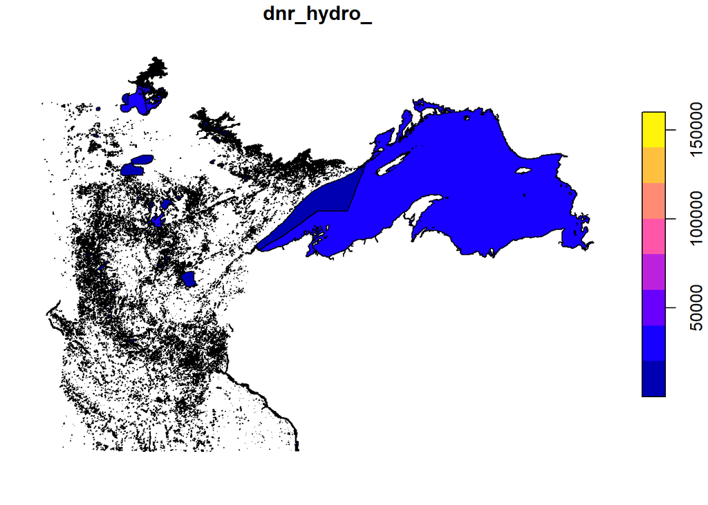

```r
plot(lakes[1])
```

So, my simple question on a Friday afternoon was, where do high density of metal air emissions overlap with surface waters that might be of interest to MPCA Water and Watershed teams?

```r
lakes <- lakes %>%
  filter(grepl("Lake", wb_class),
         outside_mn == "N",
         pw_basin_n != "Unnamed") %>%
  filter(!grepl("Pond", pw_basin_n)) %>%
  filter(!is.na(pw_basin_n))
```

Similar to the trees, I converted the mnrisks data into an sf object

```r
data <- st_as_sf(data, coords = c("long", "lat"), crs = 4326)
```

Then I checked to see if that worked

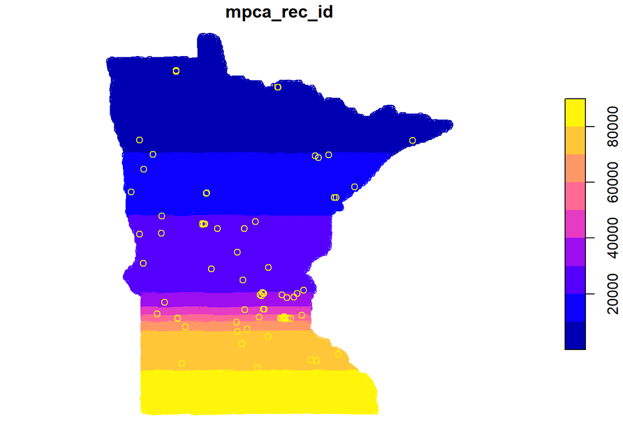

```r
plot(data[2])
```

I had to assume that the lakes and the MNRISKS data wouldn’t have the same spatial reference system. But what are they?

```r
st_crs(lakes)
```

```
## Coordinate Reference System:
##   EPSG: 26915
##   proj4string: "+proj=utm +zone=15 +datum=NAD83 +units=m +no_defs"
```

```r
st_crs(data)
```

```
## Coordinate Reference System:
##   EPSG: 4326
##   proj4string: "+proj=longlat +datum=WGS84 +no_defs"
```

So, I transformed both to be certain that the spatial reference systems would align.

```r
data <- st_transform(data, crs = 26915, proj4string = "+proj=utm +zone=15 +datum=NAD83 +units=m +no_defs")

lakes <- st_transform(lakes, crs = 26915, proj4string = "+proj=utm +zone=15 +datum=NAD83 +units=m +no_defs")
```

Then I used the st_join() function to spatially join the two data sets: one points the other polygons. The default type of join in st_join() is an intersect. There are other functions for a variety of spatial joins in the sf package.

```r
data_lakes <- st_join(lakes, data)
```

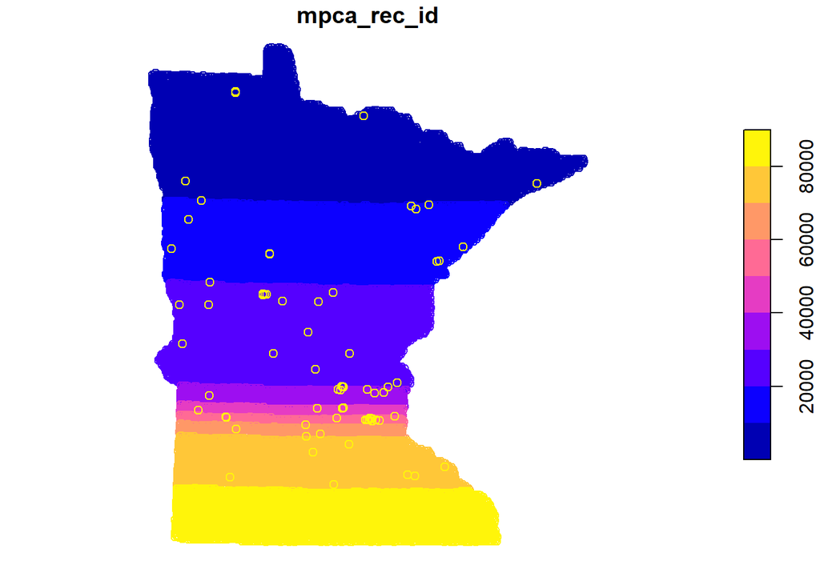

```r
plot(data[2])
```

```r
data_lakes <- data_lakes %>%
  group_by(dowlknum, pw_basin_n) %>%
  summarise(resident_cancer = max(resident_cancer),
            resident_hazard = max(resident_hazard),
            inhalation_cancer = max(inhalation_cancer),
            inhalation_hazard = max(inhalation_hazard)) %>%
  ungroup() %>%
  filter(resident_cancer > 1.5E-6)
```

Then I check the map.

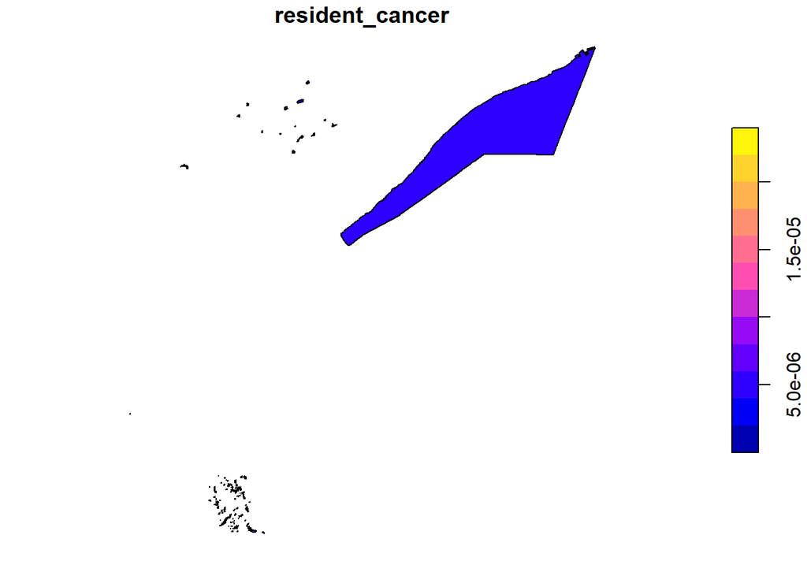

```r
plot(data_lakes[3])
```

Then I save the shapefile with the joined risks and lakes.

```r
st_write(data_lakes, dsn = "X:/Agency_Files/Outcomes/Risk_Eval_Air_Mod/_Air_Risk_Evaluation/Presentations/Ellickson_WaterMeeting_2020", layer = "high_metals", driver = "ESRI Shapefile")
```

st_write will fail if there is already a shapefile saved in the destination folder. You can add the argument delete_layer = TRUE to your st_write() function to over write that layer.

Geometry is “sticky” in the sf package. Sometimes you may want to save a dataframe of your data without the geometry.

```r
st_geometry(lakes_risks_nogeo) <- NULL

write_csv(lakes_risks, "your destination folder.csv")
```

## But those maps were so ugly Kristie. How do I make better maps?

You can use the ggplot2 package

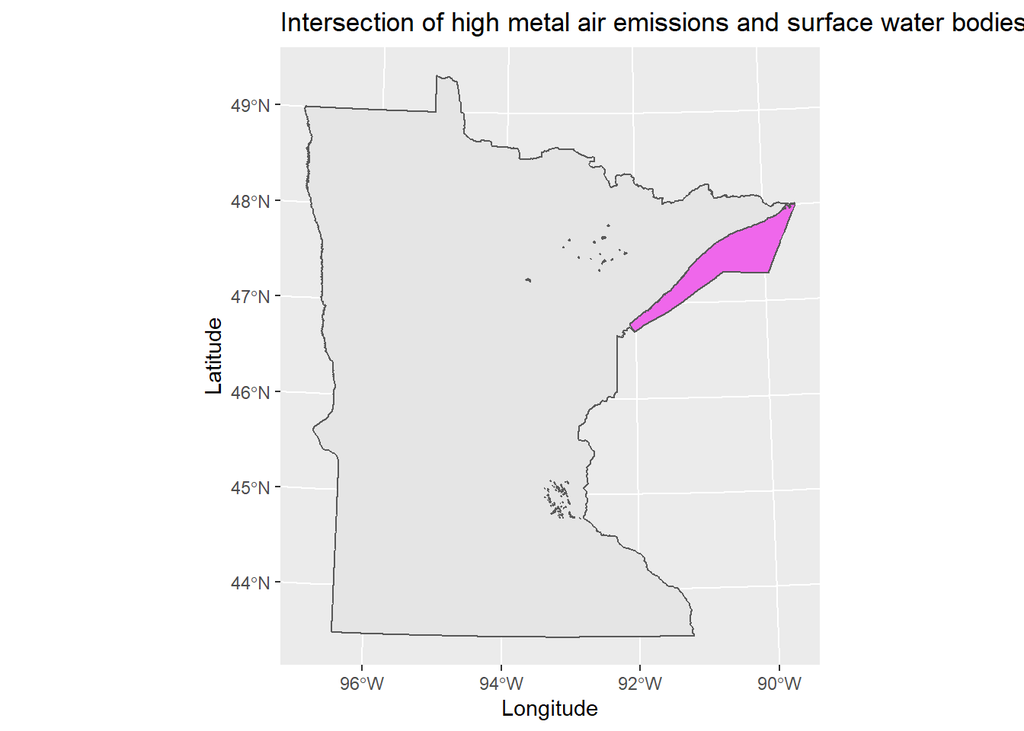

```r
library(ggplot2)

minnesota <- st_read(dsn = "R:/administrative_boundaries", layer = "state_mndot")
ggplot(data = data_lakes) +
geom_sf(data = minnesota) +
geom_sf(aes(fill = pw_basin_n)) +
theme(legend.position = "none") +
ylab("Latitude") +
xlab("Longitude") +
ggtitle("Intersection of high metal air emissions and surface water bodies")
```

But, you want to add a north arrow to the maps.

```r
#install.packages("ggsn")

library(ggsn)
```

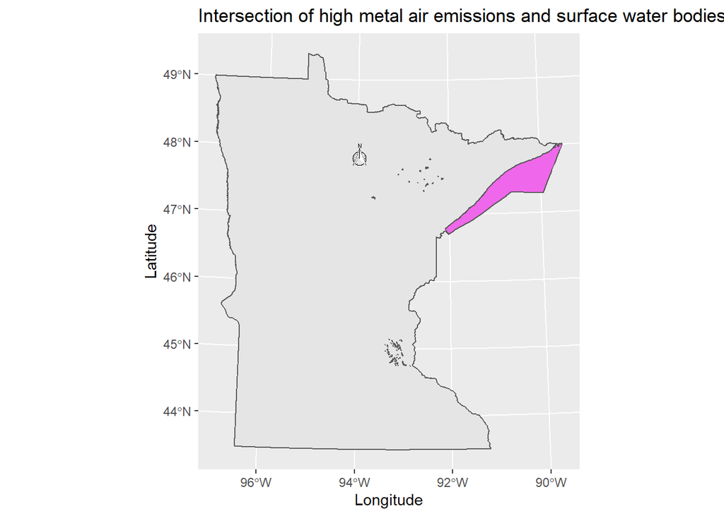

```r
ggplot(data = data_lakes) +
geom_sf(data = minnesota) +
geom_sf(aes(fill = pw_basin_n)) +
theme(legend.position = "none") +
ylab("Latitude") +
xlab("Longitude") +
ggtitle("Intersection of high metal air emissions and surface water bodies") +
north(data_lakes, location = "topleft")
```

You could also use the leaflet or plotly packages, but we will save that for another Tuesday!